# Capstone Quiz I

Complete all **Exercises**, and submit answers to **Questions** on the Coursera platform.

```r
library(ggplot2)
library(dplyr)
library(statsr)
library(GGally)
library(leaps)
library(MASS)
```

This initial quiz will concern exploratory data analysis (EDA) of the Ames Housing dataset. EDA is essential when working with any source of data and helps inform modeling.

First, let us load the data:

```r
load("ames_train.Rdata")
```

1. Which of the following are the three variables with the highest number of missing observations?
   1. `Misc.Feature`, `Fence`, `Pool.QC`
   2. `Misc.Feature`, `Alley`, `Pool.QC`
   3. `Pool.QC`, `Alley`, `Fence`
   4. `Fireplace.Qu`, `Pool.QC`, `Lot.Frontage`

```
## [1] 971
```

```
## [1] 798
```

```
## [1] 997
```

```
## [1] 933
```

```
## [1] 491
```

```
## [1] 167
```

2. How many categorical variables are coded in R as having type `int`? Change them to factors when conducting your analysis.
   1. 0
   2. 1
   3. 2
   4. 3

```r
# type your code for Question 2 here, and Knit
#str(ames_train)
#summary(ames_train)
summary(ames_train$Overall.Cond)
```

```
##    Min. 1st Qu.  Median    Mean 3rd Qu.    Max.
##   1.000   5.000   5.000   5.559   6.000   9.000
```

```r
summary(ames_train$Overall.Qual)
```

```
##    Min. 1st Qu.  Median    Mean 3rd Qu.    Max.
##   1.000   5.000   6.000   6.095   7.000  10.000
```

```r
# Overall Condition and Overall Quality could take finite values.
```

3. In terms of price, which neighborhood has the highest standard deviation?
   1. `StoneBr`
   2. `Timber`
   3. `Veenker`
   4. `NridgHt`

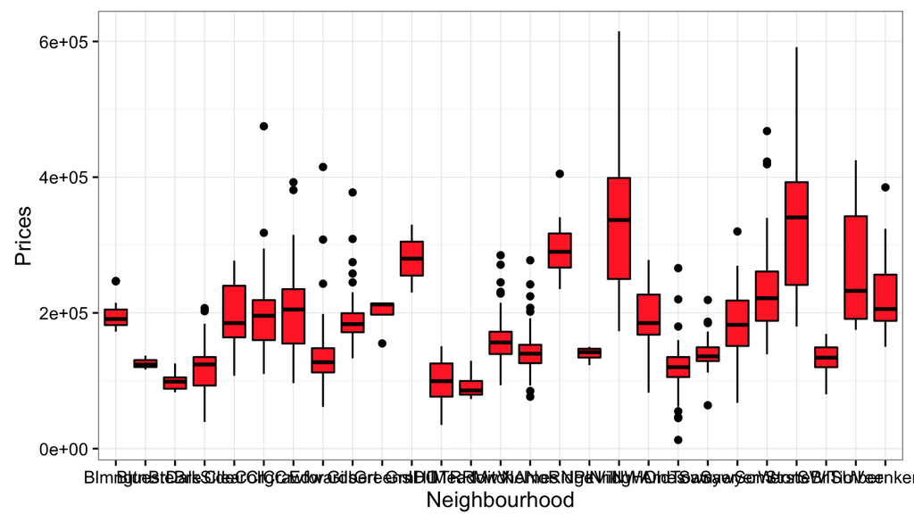

```r
# type your code for Question 3 here, and Knit
library(ggplot2)
ggplot(ames_train,aes(x=Neighborhood,y=price))+geom_boxplot(color='black',fill='firebrick1')+theme_bw()+labs(y="Prices",x="Neighbourhood")
```

```r
ames_train %>% filter(Neighborhood == "StoneBr") %>% summarise(max_S = max(price),min_S=min(price),sd_S=sd(price),avg_S=mean(price),med_S=median(price))
```

```
## # A tibble: 1 × 5
##    max_S  min_S     sd_S  avg_S    med_S
##    <int>  <int>    <dbl>  <dbl>    <dbl>
## 1 591587 180000 123459.1 339316 340691.5
```

```r
ames_train %>% filter(Neighborhood == "Timber") %>% summarise(max_T = max(price),min_T=min(price),sd_T=sd(price),avg_T=mean(price),med_T=median(price))
```

```
## # A tibble: 1 × 5
##    max_T  min_T     sd_T    avg_T  med_T
##    <int>  <int>    <dbl>    <dbl>  <int>
## 1 425000 175000 84029.57 265192.2 232500
```

```r
ames_train %>% filter(Neighborhood == "Veenker") %>% summarise(max_V = max(price),min_V=min(price),sd_V=sd(price),avg_V=mean(price),med_V=median(price))
```

```
## # A tibble: 1 × 5
##    max_V  min_V     sd_V  avg_V  med_V
##    <int>  <int>    <dbl>  <dbl>  <dbl>
## 1 385000 150000 72545.41 233650 205750
```

```r
ames_train %>% filter(Neighborhood == "NridgHt") %>% summarise(max_N = max(price),min_N=min(price),sd_N=sd(price),avg_N=mean(price),med_N=median(price))
```

```
## # A tibble: 1 × 5
##    max_N  min_N     sd_N    avg_N  med_N
##    <int>  <int>    <dbl>    <dbl>  <int>
## 1 615000 173000 105088.9 333646.7 336860
```

```r
# StoneBr has highest standard deviation in terms of the price.
```

4. Using scatter plots or other graphical displays, which of the following variables appears to be the best single predictor of `price`?
   1. `Lot.Area`
   2. `Bedroom.AbvGr`
   3. `Overall.Qual`
   4. `Year.Built`

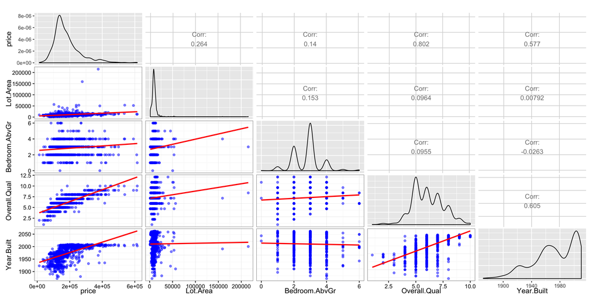

```r
# type your code for Question 4 here, and Knit
my_fn <- function(data, mapping, ...){
  p <- ggplot(data = data, mapping = mapping) +
    geom_point(pch=19,alpha=0.5,color='blue') +
    geom_smooth(method=lm, fill="red", color="red", se=FALSE, ...) +
    theme_bw()
  p
}
g = ggpairs(ames_train,columns = c(3,7,53,20,22), lower = list(continuous = my_fn))
g
```

```r
# Overall Quality looks highly correlated with price.
```

5. Suppose you are examining the relationship between `price` and `area`. Which of the following variable transformations makes the relationship appear to be the most linear?
   1. Do not transform either `price` or `area`
   2. Log-transform `price` but not `area`
   3. Log-transform `area` but not `price`
   4. Log-transform both `price` and `area`

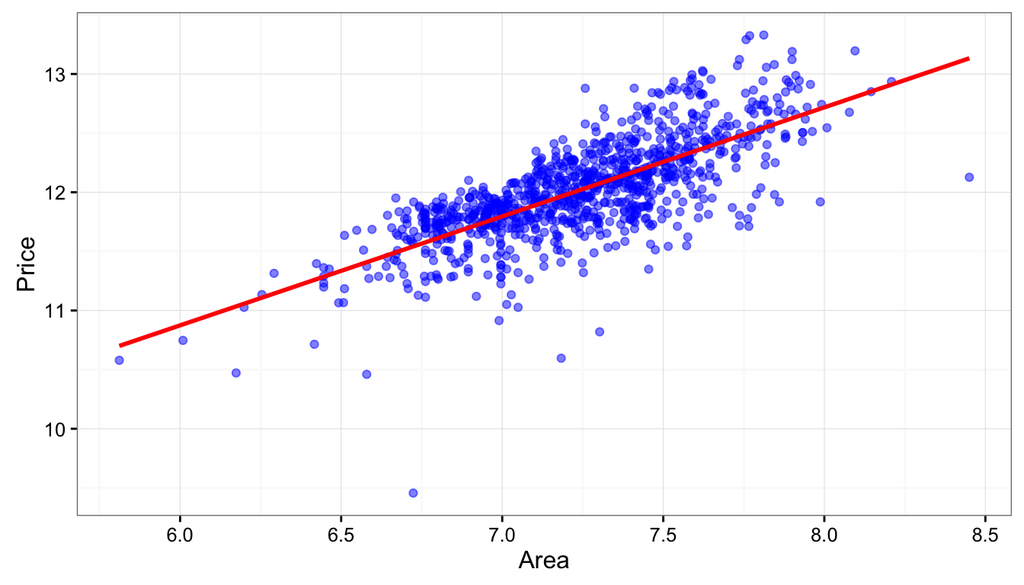

```r
# type your code for Question 5 here, and Knit
ggplot(ames_train,aes(x=log(area),y=log(price)))+geom_point(pch=19,color='blue',alpha=0.5)+geom_smooth(method=lm,color='red',se=F)+theme_bw()+labs(x="Area",y="Price")
```

```r
cor(ames_train$area,ames_train$price)
```

```
## [1] 0.7127375
```

```r
cor(log(ames_train$area),log(ames_train$price))
```

```
## [1] 0.7393174
```

```r
cor(log(ames_train$area),ames_train$price)
```

```
## [1] 0.7006098
```

```r
cor(ames_train$area,log(ames_train$price))
```

```
## [1] 0.714812
```

```r
# When both price and area are log transformed the correlation is the greatest.
```

6. Suppose that your prior for the proportion of houses that have at least one garage is Beta(9, 1). What is your posterior? Assume a beta-binomial model for this proportion.
   1. Beta(954, 46)
   2. Beta(963, 46)
   3. Beta(954, 47)
   4. Beta(963, 47)

```r
# type your code for Question 6 here, and Knit
#Beta(963,47)
```

7. Which of the following statements is true about the dataset?
   1. Over 30 percent of houses were built after the year 1999.
   2. The median housing price is greater than the mean housing price.
   3. 21 houses do not have a basement.
   4. 4 houses are located on gravel streets.

```r
# type your code for Question 7 here, and Knit
summary(ames_train$Year.Built)
```

```
##    Min. 1st Qu.  Median    Mean 3rd Qu.    Max.
##    1872    1955    1975    1972    2001    2010
```

```r
ames_train %>% summarise(mean_price = mean(price),median_price = median(price))
```

```
## # A tibble: 1 × 2
##   mean_price median_price
##        <dbl>        <dbl>
## 1   181190.1       159467
```

```r
ames_train %>% filter(Total.Bsmt.SF == 0) %>% summarise(n())
```

```
## # A tibble: 1 × 1
##   `n()`
##   <int>
## 1    21
```

```r
summary(ames_train$Street)
```

```
## Grvl Pave
##    3  997
```

```r
# 21 houses don't have a basement is true.
```

8. Test, at the $\alpha = 0.05$ level, whether homes with a garage have larger square footage than those without a garage.
   1. With a p-value near 0.000, we reject the null hypothesis of no difference.
   2. With a p-value of approximately 0.032, we reject the null hypothesis of no difference.
   3. With a p-value of approximately 0.135, we fail to reject the null hypothesis of no difference.
   4. With a p-value of approximately 0.343, we fail to reject the null hypothesis of no difference.

```r
# type your code for Question 8 here, and Knit
# p value is < .00001 so reject null hypothesis.
```

9. For homes with square footage greater than 2000, assume that the number of bedrooms above ground follows a Poisson distribution with rate $\lambda$. Your prior on $\lambda$ follows a Gamma distribution with mean 3 and standard deviation 1. What is your posterior mean and standard deviation for the average number of bedrooms in houses with square footage greater than 2000 square feet?
   1. Mean: 3.61, SD: 0.11
   2. Mean: 3.62, SD: 0.16
   3. Mean: 3.63, SD: 0.09
   4. Mean: 3.63, SD: 0.91

```r
# type your code for Question 9 here, and Knit
#bayes_inference(y=Bedroom.AbvGr,data=Bed,statistic = "mean",type="ht",null=3,alternative = "twosided")
```

10. When regressing $\log$(`price`) on $\log$(`area`), there are some outliers. Which of the following do the three most outlying points have in common?
    1. They had abnormal sale conditions.
    2. They have only two bedrooms.
    3. They have an overall quality of less than 3.
    4. They were built before 1930.

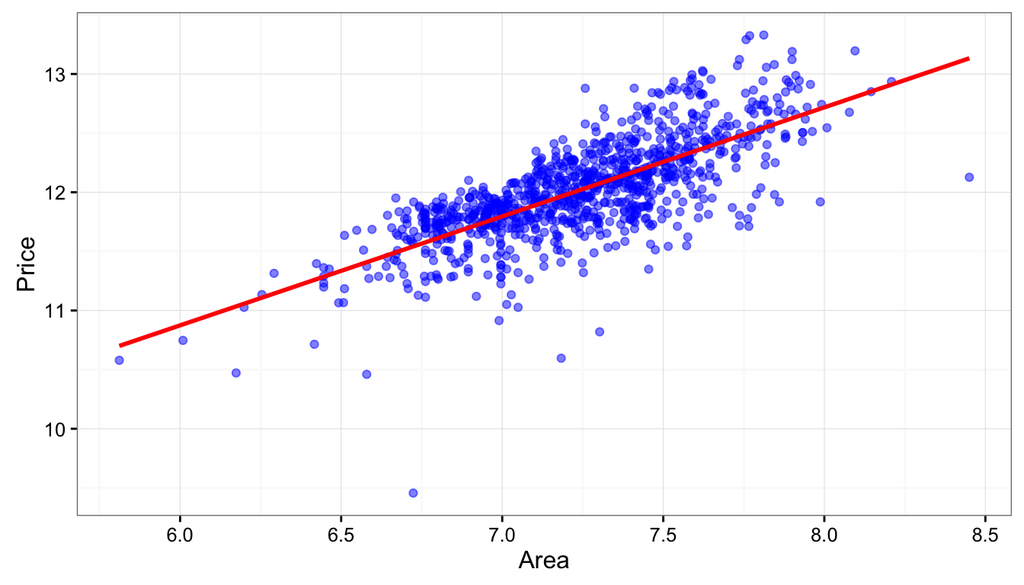

```r
# type your code for Question 10 here, and Knit
ggplot(ames_train,aes(x=log(area),y=log(price)))+geom_point(pch=19,color='blue',alpha=0.5)+geom_smooth(method=lm,color='red',se=F)+theme_bw()+labs(x="Area",y="Price")
```

```r
log_price <- log(ames_train$price)
log_area <- log(ames_train$area)
summary(log_area)
```

```
##    Min. 1st Qu.  Median    Mean 3rd Qu.    Max.
##   5.811   6.996   7.252   7.241   7.464   8.450
```

```r
IQR(log_area)
```

```
## [1] 0.4677403
```

```r
summary(log_price)
```

```
##    Min. 1st Qu.  Median    Mean 3rd Qu.    Max.
##   9.456  11.770  11.980  12.020  12.270  13.330
```

```r
IQR(log_price)
```

```
## [1] 0.495587
```

```r
# index 645,855,918 are outliers
# Overall Quality is less than 3
```

11. Which of the following are reasons to log-transform `price` if used as a dependent variable in a linear regression?
    1. `price` is right-skewed.
    2. `price` cannot take on negative values.
    3. `price` can only take on integer values.
    4. Both a and b.

```r
# type your code for Question 11 here, and Knit
#  a
```

12. How many neighborhoods consist of only single-family homes? (e.g. `Bldg.Type` = `1Fam`)
    1. 0
    2. 1
    3. 2
    4. 3

```r
# type your code for Question 12 here, and Knit
ames_train %>% group_by(Neighborhood) %>% summarise(mean(Bldg.Type=="1Fam"))
```

```
## # A tibble: 27 × 2
##    Neighborhood `mean(Bldg.Type == "1Fam")`
##          <fctr>                       <dbl>
## 1       Blmngtn                   0.1818182
## 2       Blueste                   0.0000000
## 3        BrDale                   0.0000000
## 4       BrkSide                   0.9756098
## 5       ClearCr                   1.0000000
## 6       CollgCr                   0.9647059
## 7       Crawfor                   0.8620690
## 8       Edwards                   0.8000000
## 9       Gilbert                   0.9795918
## 10       Greens                   0.0000000
## # ... with 17 more rows
```

```r
# 3 Neighborhoods consist only single family home
```

13. Using color, different plotting symbols, conditioning plots, etc., does there appear to be an association between $\log$(`area`) and the number of bedrooms above ground (`Bedroom.AbvGr`)?
    1. Yes
    2. No

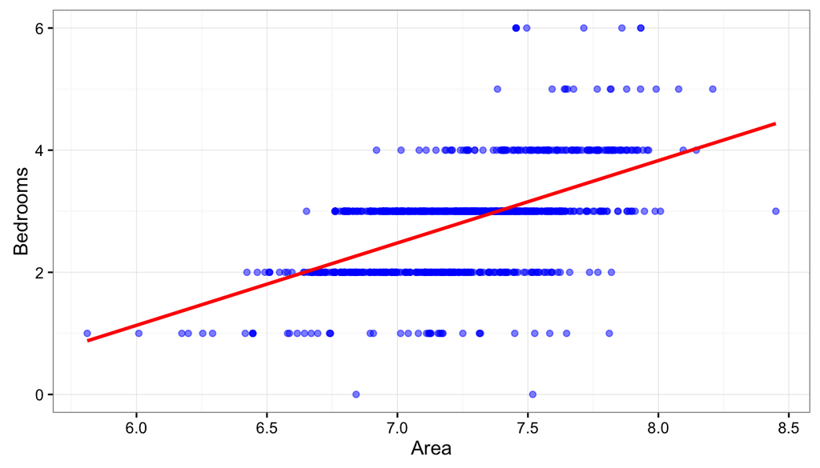

```r
# type your code for Question 13 here, and Knit
ggplot(ames_train,aes(x=log(area),y=Bedroom.AbvGr))+geom_point(pch=19,color='blue',alpha=0.5)+geom_smooth(method=lm,color='red',se=F)+theme_bw()+labs(x="Area",y="Bedrooms")
```

```r
cor(log_area,ames_train$Bedroom.AbvGr)
```

```
## [1] 0.5457625
```

14. Of the people who have unfinished basements, what is the average square footage of the unfinished basement?
    1. 590.36
    2. 595.27
    3. 614.37
    4. 681.94

```r
# type your code for Question 14 here, and Knit
r1 <- ames_train %>% filter(BsmtFin.Type.1=="Unf"| BsmtFin.Type.2=="Unf") %>% dplyr::select(Bsmt.Unf.SF)
mean(r1$Bsmt.Unf.SF)
```

```
## [1] 605.0498
```